# Etude Entreprise

Amel

2024-01-03

# Merge l’ensemble des données :

1- Il faut transformer les colonnes pour quelles aient toutes le même type de données :

```r
library(purrr)
library(dplyr)
```

```r
chemins <- c("Nettoyage_2018/enquete_2018DS-2_nettoyer.csv",
             "Nettoyage_2019/2019.csv",
             "Nettoyage_2020/enquete_2020DS_nettoyer.csv",
             "Nettoyage_2021/enquete_2021DS-2_nettoyer.csv",
             "Nettoyage_2022/enquete_2022DS-2_nettoyer.csv",
             "Nettoyage2023/enquete_2023DS-2_NR2.csv")

# Lire les fichiers
dataframes <- map(chemins, ~ read.csv(.x, sep = ","))

# Convertir la colonne 'identifiant' en double si elle est de type caractère
dataframes <- map(dataframes, ~ {
    if ('identifiant' %in% names(.x) && is.character(.x$identifiant)) {
        .x <- mutate(.x, identifiant = as.double(identifiant))
    }
    if ('duree_CDD' %in% names(.x) && is.double(.x$duree_CDD)) {
        .x <- mutate(.x, duree_CDD = as.character(duree_CDD))
    }
    if ('emploi_lie_energie_renouvelable' %in% names(.x) && is.double(.x$emploi_lie_energie_renouvelable)) {
        .x <- mutate(.x, emploi_lie_energie_renouvelable = as.character(emploi_lie_energie_renouvelable))
    }
    if ('jours_télétravail' %in% names(.x) && is.double(.x$jours_télétravail)) {
        .x <- mutate(.x, jours_télétravail = as.character(jours_télétravail))
    }
    return(.x)
})
merged_data <- bind_rows(dataframes, .id = "SourceFile")
```

```
## • `Quel.est.le.statut.de.votre.employeur...entreprise...1` ->
##   `Quel.est.le.statut.de.votre.employeur...entreprise`
```

2. ensuite je stock ça dans un fichier csv :

```r
  write.csv(merged_data, file = "./merged_database.csv", row.names = FALSE)
```

# Sélection des éléments dont j’ai besoin pour mon étude

Je fais l’étude du salaire en fonction des différents factueurs de l’entreprise, ainsi pour ça j’ai sélectionné les colonnes qui me paraissaient pertinante pour cette étude :

```r
library(dplyr)

# Lire le fichier CSV
data <- read.csv("merged_database.csv", header = TRUE)

# Sélectionner les colonnes spécifiques
attribut_entreprise <- data %>%
  select(identifiant, nature_contrat, localisation_emploi, region_emploi, entreprise_groupe, groupe,
         intitule_emploi, remuneration_annuelle_brute, prime, remuneration_prime,
         taille_entreprise_premier_emploi, secteur_premiere_entreprise, status_cadre_premier_emploi,
         nom_entreprise_premier_emploi, taille_entreprise)

# Afficher les premières lignes pour vérifier les données sélectionnées
head(attribut_entreprise)
```

```
##    identifiant                                               nature_contrat
## 1 1.877070e+15 CDI (contrat de travail à durée indéterminée) y compris CDIC
## 2 1.867773e+15 CDI (contrat de travail à durée indéterminée) y compris CDIC
## 3 1.783165e+15 CDI (contrat de travail à durée indéterminée) y compris CDIC
## 4 1.777070e+15
## 5 1.885320e+15
## 6 1.782336e+15 CDI (contrat de travail à durée indéterminée) y compris CDIC
##   localisation_emploi        region_emploi entreprise_groupe groupe
## 1           En France Auvergne-Rhône-Alpes               Non
## 2           En France        Île-de-France               Oui Apside
## 3           En France        Île-de-France               Oui
## 4
## 5
## 6           En France Auvergne-Rhône-Alpes               Non
##                           intitule_emploi remuneration_annuelle_brute prime
## 1       Ingénieur développement logiciels                       31500   Non
## 2                          Ingenieur FPGA                       33000   Oui
## 3 Ingénieur Traitement d'images embarqué                        36000   Oui
## 4                                                                  NA
## 5                                                                  NA
## 6            Ingénieur Model Based Design                       32000   Non
##   remuneration_prime taille_entreprise_premier_emploi
## 1              31500
## 2              33000
## 3              36000
## 4                 NA         Moins de 10 salarié(e)s
## 5                 NA
## 6              32000
##   secteur_premiere_entreprise status_cadre_premier_emploi
## 1
## 2
## 3
## 4            Autres secteurs                          Oui
## 5
## 6
##   nom_entreprise_premier_emploi         taille_entreprise
## 1                                 De 20 à 49 salarié(e)s
## 2                               250 à  4 999 salarié(e)s
## 3                                 De 20 à 49 salarié(e)s
## 4                       IoTerop
## 5
## 6                               5 000 salarié(e)s ou plus
```

```r
write.csv(attribut_entreprise, file = "./etude_entreprise.csv", row.names = FALSE)
```

# Les études sur mes données :

## 1) Anova univarible sur l’attribut nature de contrat en fonction de la variable remuneration:

```r
nature_contrat_anova <- aov(remuneration_prime ~ nature_contrat, data = attribut_entreprise)
summary(nature_contrat_anova)
```

```
##                  Df    Sum Sq   Mean Sq F value Pr(>F)
## nature_contrat   30 1.686e+10 561967856   6.079 <2e-16 ***
## Residuals      3012 2.785e+11  92449724
## ---
## Signif. codes:  0 '***' 0.001 '**' 0.01 '*' 0.05 '.' 0.1 ' ' 1
## 1376 observations deleted due to missingness
```

1.1 représentation graphique :

```r
# Compter la fréquence des types de contrats
freq_contrats <- table(nature_contrat_anova$nature_contrat)

# Trier les fréquences par ordre décroissant
sorted_freq <- sort(freq_contrats, decreasing = TRUE)

# Afficher les types de contrats les plus fréquents
head(sorted_freq, 10)
```

```
## integer(0)
```

[figure not shown]

```r
library(ggplot2)
  ggplot(nature_contrat_anova, aes(x = factor(nature_contrat), y = remuneration_prime)) +
  geom_boxplot() +
  labs(x = "Nature du contrat", y = "Rémunération Prime") +
  ggtitle("Variation de la rémunération Prime par nature de contrat")
```

### Résultat :

Ce résultat provient d’une analyse de variance (ANOVA) qui a été effectuée sur la variable remuneration_prime en fonction de la variable nature_contrat. Voici ce que signifient les différentes parties de la sortie :

Df: Degré de liberté, indique le nombre de catégories moins un. Sum Sq: Somme des carrés, représente la variation totale expliquée par le modèle. Mean Sq: Moyenne des carrés, correspond à la variation moyenne entre les groupes. F value: Valeur de test de Fisher, permet de tester si la moyenne des groupes est significativement différente. Pr(>F): Valeur p associée à la statistique F, indique la probabilité que les résultats observés soient dus au hasard.

Dans votre cas, la variable nature_contrat semble avoir une influence significative sur la variable remuneration_prime, car la valeur p (<2e-16) est très petite, ce qui suggère que les moyennes des groupes sont différentes.

## 2) Anova univarible sur l’attribut localisation de l’emploi en fonction de la remuneration:

> la localisation c’est pour savoir si l’entreprise est en France ou à l’étranger

```r
anova_localisation_emploi <- aov(remuneration_prime ~ localisation_emploi, data = attribut_entreprise)
summary(anova_localisation_emploi)
```

```
##                       Df    Sum Sq   Mean Sq F value Pr(>F)
## localisation_emploi    3 1.827e+10 6.089e+09   66.79 <2e-16 ***
## Residuals           3039 2.770e+11 9.116e+07
## ---
## Signif. codes:  0 '***' 0.001 '**' 0.01 '*' 0.05 '.' 0.1 ' ' 1
## 1376 observations deleted due to missingness
```

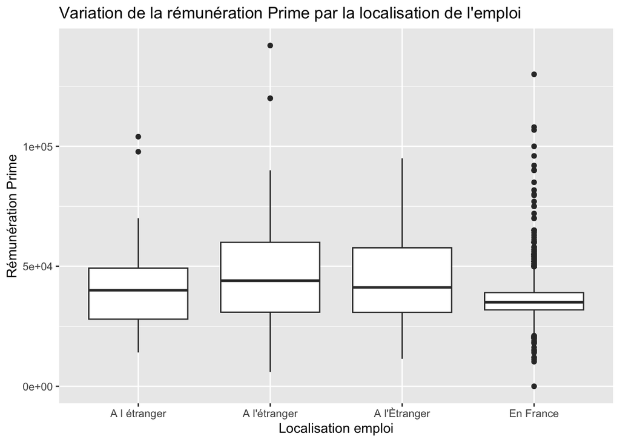

```r
library(ggplot2)

ggplot(anova_localisation_emploi, aes(x = localisation_emploi, y = remuneration_prime)) +
  geom_boxplot() +
  labs(x = "Localisation emploi", y = "Rémunération Prime") +
  ggtitle("Variation de la rémunération Prime par la localisation de l'emploi")
```

### Résultats :

Pr(>F) : C’est la valeur p associée à la valeur F calculée. Elle indique la probabilité d’obtenir un résultat aussi extrême que celui observé, si l’hypothèse nulle (absence de différence significative entre les groupes) était vraie. Une valeur p inférieure à 0.05 (dans ce cas, <2e-16) est généralement considérée comme statistiquement significative. Ici, la valeur p est très proche de zéro, indiquant une très forte signification statistique.

## 3) Anova univarible sur la variable région de l’emploi en fonction de la remuneration :

```r
  anova_region_emploi <- aov(remuneration_prime ~ region_emploi, data = attribut_entreprise)
  summary(anova_region_emploi)
```

```
##                 Df    Sum Sq   Mean Sq F value Pr(>F)
## region_emploi   25 2.952e+10 1.181e+09    13.4 <2e-16 ***
## Residuals     3017 2.658e+11 8.810e+07
## ---
## Signif. codes:  0 '***' 0.001 '**' 0.01 '*' 0.05 '.' 0.1 ' ' 1
## 1376 observations deleted due to missingness
```

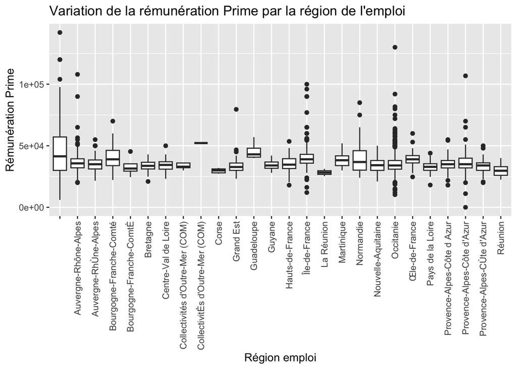

```r
ggplot(anova_region_emploi, aes(x = factor(region_emploi), y = remuneration_prime)) +
  geom_boxplot() +
  labs(x = "Région emploi", y = "Rémunération Prime") +
  ggtitle("Variation de la rémunération Prime par la région de l'emploi") +
  theme(axis.text.x = element_text(angle = 90, vjust = 0.5, hjust=1))
```

### Résultat :

Pr(>F) : Valeur p. C’est la probabilité de voir des résultats aussi extrêmes que ceux observés dans les données si l’hypothèse nulle est vraie. Ici, une valeur de <2e-16 (pratiquement 0) indique que la variable region_emploi a une influence significative sur la variable remuneration_prime. En d’autres termes, il y a de fortes chances que la rémunération soit significativement différente entre différentes régions.

## 4) Anova univarible sur la variable de si l’entreprise appartient à un groupe en fonction de la remuneration :

```r
  anova_entreprise_groupe <- aov(remuneration_prime ~ entreprise_groupe, data = attribut_entreprise)
  summary(anova_entreprise_groupe)
```

```
##                     Df    Sum Sq   Mean Sq F value  Pr(>F)
## entreprise_groupe    2 2.621e+09 1.311e+09   13.61 1.3e-06 ***
## Residuals         3040 2.927e+11 9.628e+07
## ---
## Signif. codes:  0 '***' 0.001 '**' 0.01 '*' 0.05 '.' 0.1 ' ' 1
## 1376 observations deleted due to missingness
```

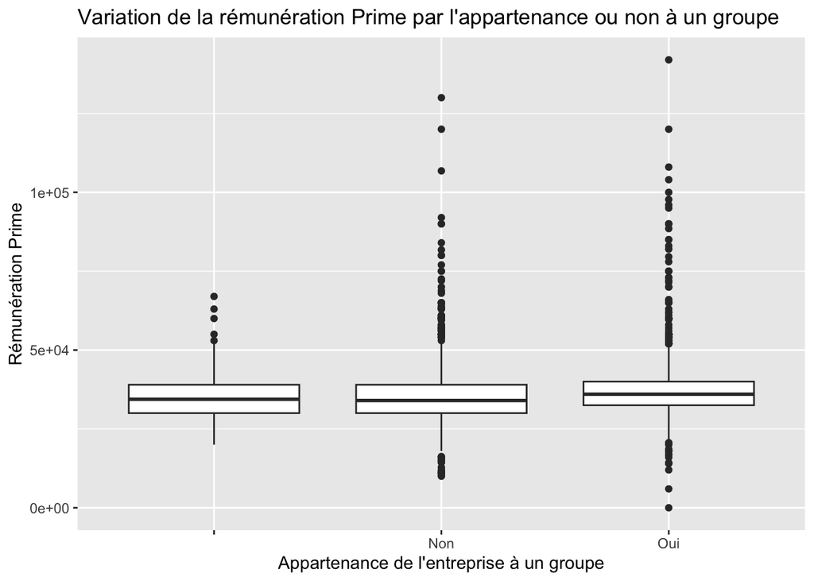

```r
ggplot(anova_entreprise_groupe, aes(x = entreprise_groupe, y = remuneration_prime)) +
  geom_boxplot() +
  labs(x = "Appartenance de l'entreprise à un groupe", y = "Rémunération Prime") +
  ggtitle("Variation de la rémunération Prime par l'appartenance ou non à un groupe")
```

### Résultat

Nous avons une influence significative de l’appartenance de l’entreprise à un groupe, on peut voir que ceux appartenant à un groupe sont légèrement mieux payer que les autres

## 5) Anova univarible sur la variable de la taille de l’entreprise en fonction de la remuneration :

```r
  anova_taille_entreprise<- aov(remuneration_prime ~ taille_entreprise, data = attribut_entreprise)
  summary(anova_taille_entreprise)
```

```
##                     Df    Sum Sq   Mean Sq F value   Pr(>F)
## taille_entreprise   11 4.453e+09 404813925   5.095 7.22e-08 ***
## Residuals         1470 1.168e+11  79456257
## ---
## Signif. codes:  0 '***' 0.001 '**' 0.01 '*' 0.05 '.' 0.1 ' ' 1
## 2937 observations deleted due to missingness
```

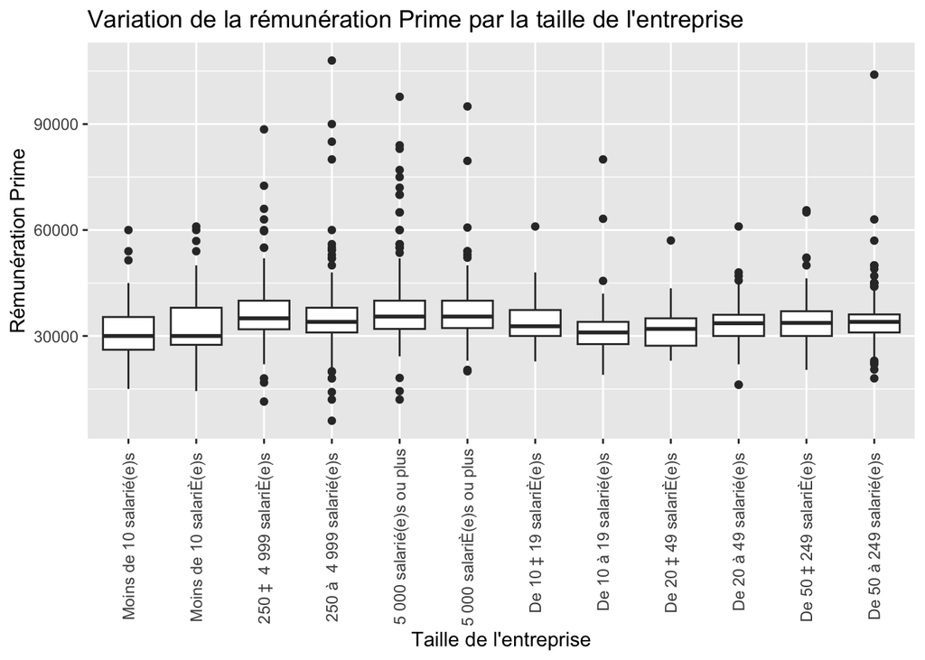

```r
ggplot(anova_taille_entreprise, aes(x = factor(taille_entreprise), y = remuneration_prime)) +
  geom_boxplot() +
  labs(x = "Taille de l'entreprise", y = "Rémunération Prime") +
  ggtitle("Variation de la rémunération Prime par la taille de l'entreprise") +
  theme(axis.text.x = element_text(angle = 90, vjust = 0.5, hjust=1))
```

### Résultat D’après notre anova, nous pouvons noter une influece significative de la taille de l’entreprise sur la rémunération de ses employés, en effet les grandes entreprises ont tendance à mieux rémunérer leurs salariés

## 5) Anova 2 variables sur la variable de la taille de l’entreprise et la région de l’entreprise en fonction de la remuneration :

```r
# ANOVA pour évaluer l'impact de la région de l'emploi et de la taille de l'entreprise sur la rémunération prime
anova_region_taille <- aov(remuneration_prime ~ region_emploi * taille_entreprise, data = attribut_entreprise)

# Affichage des résultats
summary(anova_region_taille)
```

```
##                                   Df    Sum Sq   Mean Sq F value   Pr(>F)
## region_emploi                     23 1.190e+10 517452713   7.490  < 2e-16 ***
## taille_entreprise                 11 4.672e+09 424717007   6.147 6.44e-10 ***
## region_emploi:taille_entreprise  111 1.238e+10 111520459   1.614 0.000105 ***
## Residuals                       1336 9.230e+10  69088010
## ---
## Signif. codes:  0 '***' 0.001 '**' 0.01 '*' 0.05 '.' 0.1 ' ' 1
## 2937 observations deleted due to missingness
```

### Résultat :

l’interaction entre region_emploi et taille_entreprise met en évidence une interaction significative entre la région de l’emploi et la taille de l’entreprise sur la rémunération prime. Cela signifie que l’influence de la taille de l’entreprise sur la rémunération peut varier en fonction de la région de l’emploi, et vice versa.